# Selection Sort

The selection sort algorithm sorts an array by repeatedly finding the minimum element (considering ascending order) from unsorted part and putting it at the beginning. The algorithm maintains two subarrays in a given array.

- The subarray which is already sorted.
- Remaining subarray which is unsorted.

In every iteration of selection sort, the minimum element (considering ascending order) from the unsorted subarray is picked and moved to the sorted subarray.

```
Best      Average   Worst
Ω(n^2)    θ(n^2)    O(n^2)


arr[] = 64 25 12 22 11

// Find the minimum element in arr[0...4]
// and place it at beginning
11 25 12 22 64

// Find the minimum element in arr[1...4]
// and place it at beginning of arr[1...4]
11 12 25 22 64

// Find the minimum element in arr[2...4]
// and place it at beginning of arr[2...4]
11 12 22 25 64

// Find the minimum element in arr[3...4]
// and place it at beginning of arr[3...4]
11 12 22 25 64
```

```python
def selection_sort(a):
    for i in range(len(a)):
        #Find Minmum
        min_idx = i
        for j in range(i+1, len(a)):
            if a[min_idx] > a[j]:
                min_idx = j
        a[min_idx], a[i] = a[i], a[min_idx]

        print(i, min_idx, a )
    return a
```

```python
a = [64, 25, 12, 22, 11]
print(a)
```

```
[64, 25, 12, 22, 11]
```

```python
selection_sort(a.copy())
```

```
0 4 [11, 25, 12, 22, 64]
1 2 [11, 12, 25, 22, 64]
2 3 [11, 12, 22, 25, 64]
3 3 [11, 12, 22, 25, 64]
4 4 [11, 12, 22, 25, 64]
```

```
[11, 12, 22, 25, 64]
```

# Bubble Sort

Bubble Sort is the simplest sorting algorithm that works by repeatedly swapping the adjacent elements if they are in wrong order.

```
Best    Average Worst
Ω(n)    θ(n^2)  O(n^2)
```

Example:

```
First Pass:
( 5 1 4 2 8 ) –> ( 1 5 4 2 8 ), Here, algorithm compares the first two elements, and swaps since 5 > 1.
( 1 5 4 2 8 ) –>  ( 1 4 5 2 8 ), Swap since 5 > 4
( 1 4 5 2 8 ) –>  ( 1 4 2 5 8 ), Swap since 5 > 2
( 1 4 2 5 8 ) –> ( 1 4 2 5 8 ), Now, since these elements are already in order (8 > 5), algorithm does not swap them.

Second Pass:
( 1 4 2 5 8 ) –> ( 1 4 2 5 8 )
( 1 4 2 5 8 ) –> ( 1 2 4 5 8 ), Swap since 4 > 2
( 1 2 4 5 8 ) –> ( 1 2 4 5 8 )
( 1 2 4 5 8 ) –>  ( 1 2 4 5 8 )
Now, the array is already sorted, but our algorithm does not know if it is completed. The algorithm needs one whole pass without any swap to know it is sorted.

Third Pass:
( 1 2 4 5 8 ) –> ( 1 2 4 5 8 )
( 1 2 4 5 8 ) –> ( 1 2 4 5 8 )
( 1 2 4 5 8 ) –> ( 1 2 4 5 8 )
( 1 2 4 5 8 ) –> ( 1 2 4 5 8 )
```

```python
def bubble_sort(a):
    iteration = 0
    sort = True
    while sort:
        sort = False
        for i in range(len(a)-1-iteration):
            if a[i] > a [i+1]:
                a[i], a[i+1] = a[i+1], a[i]
                sort = True
        iteration += 1
        print(iteration, sort, a)
    return a
```

```python
bubble_sort(a.copy())
```

```
1 True [25, 12, 22, 11, 64]
2 True [12, 22, 11, 25, 64]
3 True [12, 11, 22, 25, 64]
4 True [11, 12, 22, 25, 64]
5 False [11, 12, 22, 25, 64]
```

```
[11, 12, 22, 25, 64]
```

# Insertion Sort

Insertion sort is a simple sorting algorithm that works the way we sort playing cards in our hands. Algorithm // Sort an arr[] of size n insertionSort(arr, n) Loop from i = 1 to n-1. ……a) Pick element arr[i] and insert it into sorted sequence arr[0…i-1]

```
Best    Average Worst
Ω(n)    θ(n^2)  O(n^2)
```

Example:

```
12, 11, 13, 5, 6

Let us loop for i = 1 (second element of the array) to 4 (last element of the array)

i = 1. Since 11 is smaller than 12, move 12 and insert 11 before 12
11, 12, 13, 5, 6

i = 2. 13 will remain at its position as all elements in A[0..I-1] are smaller than 13
11, 12, 13, 5, 6

i = 3. 5 will move to the beginning and all other elements from 11 to 13 will move one position ahead of their current position.
5, 11, 12, 13, 6

i = 4. 6 will move to position after 5, and elements from 11 to 13 will move one position ahead of their current position.
5, 6, 11, 12, 13
```

```python
def insertion_sort(a):
    print(a)
    for i in range(1, len(a)):
        for j in range(i, 0, -1):
            if a[j-1] > a[j]:
                a[j], a[j-1] = a[j-1], a[j]
            else:
                break
        print(i, a)
    return a
```

```python
insertion_sort(a.copy())
```

```
[64, 25, 12, 22, 11]
1 [25, 64, 12, 22, 11]
2 [12, 25, 64, 22, 11]
3 [12, 22, 25, 64, 11]
4 [11, 12, 22, 25, 64]
```

```
[11, 12, 22, 25, 64]
```

# Merge Sort

```
Best            Average     Worst
Ω(nlog(n))  θ(nlog(n))  O(nlog(n))

MergeSort(arr[], l,  r)
If r > l
     1. Find the middle point to divide the array into two halves:
             middle m = (l+r)/2
     2. Call mergeSort for first half:
             Call mergeSort(arr, l, m)
     3. Call mergeSort for second half:
             Call mergeSort(arr, m+1, r)
     4. Merge the two halves sorted in step 2 and 3:
             Call merge(arr, l, m, r)
```

The following diagram from wikipedia shows the complete merge sort process for an example array {38, 27, 43, 3, 9, 82, 10}. If we take a closer look at the diagram, we can see that the array is recursively divided in two halves till the size becomes 1. Once the size becomes 1, the merge processes comes into action and starts merging arrays back till the complete array is merged.

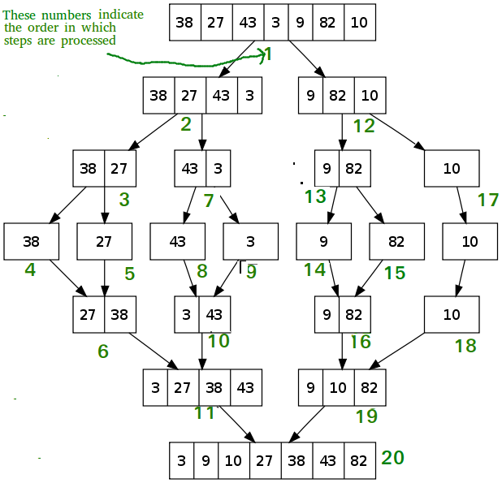

```python
def merge(left, right):
    print(left, right, "merge")
    i = 0
    j = 0
    a = []
    while i < len(left) and j < len(right):
        if left[i] <= right[j]:
            a.append(left[i])
            i += 1
        else:
            a.append(right[j])
            j += 1
    while i < len(left):
        a.append(left[i])
        i += 1
    while j < len(right):
        a.append(right[j])
        j += 1
    return a
```

```python
l = [1, 4, 6 , 7]
r = [0, 2]
merge(l, r)
```

```
[1, 4, 6, 7] [0, 2] merge
```

```
[0, 1, 2, 4, 6, 7]
```

```python
def merge_sort(a):
    if len(a) == 1:
        pass
    else:
        l = merge_sort(a[:len(a)//2])
        r = merge_sort(a[len(a)//2:])
        a = merge(l, r)
    return a
```

```python
def merge2(left, right, a):
    print(left, right, a)
    i = j = k = 0
    while i < len(left) and j < len(right):
        if left[i] <= right[j]:
            a[k] = left[i]
            i += 1
            k += 1
        else:
            a[k] = right[j]
            k += 1
            j += 1
    while i < len(left):
        a[k] = left[i]
        k += 1
        i += 1
    while j < len(right):
        a[k] = right[j]
        k += 1
        j += 1
```

```python
def merge_sort2(a):
    if len(a) == 1:
        pass
    else:
        l = merge_sort2(a[:len(a)//2])
        r = merge_sort2(a[len(a)//2:])
        merge2(l, r, a)
    return a
```

```python
k = merge_sort2(a.copy())
k
```

```
[64] [25] [64, 25]
[22] [11] [22, 11]
[12] [11, 22] [12, 22, 11]
[25, 64] [11, 12, 22] [64, 25, 12, 22, 11]
```

```
[11, 12, 22, 25, 64]
```

# Heap Sort

Heap sort is a comparison based sorting technique based on Binary Heap data structure. It is similar to selection sort where we first find the maximum element and place the maximum element at the end. We repeat the same process for remaining element.

```
Best            Average     Worst
Ω(nlog(n))  θ(nlog(n))  O(nlog(n))
```

What is Binary Heap? Let us first define a Complete Binary Tree. A complete binary tree is a binary tree in which every level, except possibly the last, is completely filled, and all nodes are as far left as possible (Source Wikipedia)

A Binary Heap is a Complete Binary Tree where items are stored in a special order such that value in a parent node is greater(or smaller) than the values in its two children nodes. The former is called as max heap and the latter is called min heap. The heap can be represented by binary tree or array.

Why array based representation for Binary Heap? Since a Binary Heap is a Complete Binary Tree, it can be easily represented as array and array based representation is space efficient. If the parent node is stored at index I, the left child can be calculated by 2 *I + 1 and right child by 2* I + 2 (assuming the indexing starts at 0).

Heap Sort Algorithm for sorting in increasing order:

1. Build a max heap from the input data.
2. At this point, the largest item is stored at the root of the heap. Replace it with the last item of the heap followed by reducing the size of heap by 1. Finally, heapify the root of tree.
3. Repeat above steps while size of heap is greater than 1.

How to build the heap? Heapify procedure can be applied to a node only if its children nodes are heapified. So the heapification must be performed in the bottom up order.

Lets understand with the help of an example:

```
Input data: 4, 10, 3, 5, 1
         4(0)
        /   \
     10(1)   3(2)
    /   \
 5(3)    1(4)

The numbers in bracket represent the indices in the array
representation of data.

Applying heapify procedure to index 1:
         4(0)
        /   \
    10(1)    3(2)
    /   \
5(3)    1(4)

Applying heapify procedure to index 0:
        10(0)
        /  \
     5(1)  3(2)
    /   \
 4(3)    1(4)
The heapify procedure calls itself recursively to build heap
 in top down manner.
```

```python
# To heapify subtree rooted at index i.
# n is size of heap
def heapify(arr, n, i):
    largest = i # Initialize largest as root
    l = 2 * i + 1     # left = 2*i + 1
    r = 2 * i + 2     # right = 2*i + 2
    if l >= n and r >= n:
        print(len(arr), n, i, l, r)
        return
    #print(" ", arr, n, i, l, r)

    # See if left child of root exists and is
    # greater than root
    if l < n and arr[i] < arr[l]:
        largest = l

    # See if right child of root exists and is
    # greater than root
    if r < n and arr[largest] < arr[r]:
        largest = r

    # Change root, if needed
    if largest != i:
        arr[i],arr[largest] = arr[largest],arr[i] # swap

        # Heapify the root.
        heapify(arr, n, largest)
    return arr
```

```python
import random
arr = [random.randint(1, 100) for i in range(100) ]
print(arr)
for i in range((len(arr)+1) // 2, -1, -1):
    print("->",arr, len(arr), i)
    heapify(arr, len(arr), i)
```

[output not shown]

[output cut: 62 more lines]

```python
def heap_sort(a):
    n = len(a)

    #Build max
    for i in range(n, -1, -1):
        heapify(a, n, i)

    #Get max
    heapsize = n
    for i in range(0, n):
        heapsize -= 1
        a[heapsize], a[0] = a[0], a[heapsize]
        heapify(a, heapsize, 0)
    return a
```

```python
srt = heap_sort(arr)
print(srt)
```

```
100 100 100 201 202
100 100 99 199 200
100 100 98 197 198
100 100 97 195 196
100 100 96 193 194
100 100 95 191 192
100 100 94 189 190
100 100 93 187 188
100 100 92 185 186
100 100 91 183 184
100 100 90 181 182
100 100 89 179 180
100 100 88 177 178
100 100 87 175 176
100 100 86 173 174
```

[output cut: 596 more lines]

# Quick Sort

Like Merge Sort, QuickSort is a Divide and Conquer algorithm. It picks an element as pivot and partitions the given array around the picked pivot. There are many different versions of quickSort that pick pivot in different ways.

```
Best            Average  Worst
Ω(nlog(n))  θ(nlog(n))  O(n^2)
```

```python
a = [64, 25, 12, 22, 11, 12]
```

```python
def quick_sort(a):
    print("quick_sort", locals())
    piovt(a, 0, len(a)-1)
    return a

def piovt(a, l, r):
    print("piovt", locals())
    if l >= r:
        return
    p = a[(l+r)//2]
    i = partition(a, l, r, p)
    piovt(a, l, i-1)
    piovt(a, i, r)

def partition(a, l, r, p):
    print("parition-e", locals())
    while l <= r:
        while l < len(a) and a[l] < p: l += 1
        while r >= 0 and a[r] > p: r -= 1
        if l < r:
            print("parition-l", locals(), a[l], a[r])
            a[l], a[r] = a[r], a[l]
        l += 1
        r -= 1
    print("parition-E", locals())
    return l
```

```python
quick_sort(a.copy())
```

```
quick_sort {'a': [64, 25, 12, 22, 11, 12]}
piovt {'a': [64, 25, 12, 22, 11, 12], 'l': 0, 'r': 5}
parition-e {'a': [64, 25, 12, 22, 11, 12], 'l': 0, 'r': 5, 'p': 12}
parition-l {'a': [64, 25, 12, 22, 11, 12], 'l': 0, 'r': 5, 'p': 12} 64 12
parition-l {'a': [12, 25, 12, 22, 11, 64], 'l': 1, 'r': 4, 'p': 12} 25 11
parition-E {'a': [12, 11, 12, 22, 25, 64], 'l': 3, 'r': 1, 'p': 12}
piovt {'a': [12, 11, 12, 22, 25, 64], 'l': 0, 'r': 2}
parition-e {'a': [12, 11, 12, 22, 25, 64], 'l': 0, 'r': 2, 'p': 11}
parition-l {'a': [12, 11, 12, 22, 25, 64], 'l': 0, 'r': 1, 'p': 11} 12 11
parition-E {'a': [11, 12, 12, 22, 25, 64], 'l': 1, 'r': 0, 'p': 11}
piovt {'a': [11, 12, 12, 22, 25, 64], 'l': 0, 'r': 0}
piovt {'a': [11, 12, 12, 22, 25, 64], 'l': 1, 'r': 2}
parition-e {'a': [11, 12, 12, 22, 25, 64], 'l': 1, 'r': 2, 'p': 12}
parition-l {'a': [11, 12, 12, 22, 25, 64], 'l': 1, 'r': 2, 'p': 12} 12 12
parition-E {'a': [11, 12, 12, 22, 25, 64], 'l': 2, 'r': 1, 'p': 12}
piovt {'a': [11, 12, 12, 22, 25, 64], 'l': 1, 'r': 1}
piovt {'a': [11, 12, 12, 22, 25, 64], 'l': 2, 'r': 2}
piovt {'a': [11, 12, 12, 22, 25, 64], 'l': 3, 'r': 5}
parition-e {'a': [11, 12, 12, 22, 25, 64], 'l': 3, 'r': 5, 'p': 25}
parition-E {'a': [11, 12, 12, 22, 25, 64], 'l': 5, 'r': 3, 'p': 25}
piovt {'a': [11, 12, 12, 22, 25, 64], 'l': 3, 'r': 4}
parition-e {'a': [11, 12, 12, 22, 25, 64], 'l': 3, 'r': 4, 'p': 22}
parition-E {'a': [11, 12, 12, 22, 25, 64], 'l': 4, 'r': 2, 'p': 22}
piovt {'a': [11, 12, 12, 22, 25, 64], 'l': 3, 'r': 3}
piovt {'a': [11, 12, 12, 22, 25, 64], 'l': 4, 'r': 4}
piovt {'a': [11, 12, 12, 22, 25, 64], 'l': 5, 'r': 5}
```

```
[11, 12, 12, 22, 25, 64]
```